# The effect of misinformation on vaccine uptake: the case of South Wales

Jaakko

16 March 2022

## 1. Introduction

“The spread of SARS-CoV-2, the causative agent of COVID-19, has resulted in an unprecedented global public health and economic crisis” [^1]. As a result, the World Health Organization (WHO) declared a pandemic on 11 March 2020. The development of COVID-19 vaccines has been a significant undertaking in fighting the disease; nevertheless, as countries developed vaccines, misinformation spread rapidly through online channels such as news outlets, websites, and social media[^2].

Covid-19 is not the only disease where misinformation has spread, “despite the availability of safe and effective vaccines; several European countries are experiencing outbreaks of vaccine-preventable diseases.[^3]” The European Observatory on Health Systems and Policies conjectures that one reason for the outbreaks is extensive misinformation about vaccines.

The seriousness of misinformation relies on the public’s vaccine hesitancy; misinformation motivates skepticism towards vaccines and ultimately hesitation on vaccine uptake [^4] causing the further spread of the disease and increasing public costs. Therefore vaccine hesitancy plays an essential role in decreasing vaccination rates, and that’s why Who considered it a top ten global threat to public health[^5]. Some countries are currently addressing the misinformation issue, but the effort might not be sufficient.

The negative relationship between misinformation and vaccine hesitancy (or vaccine rate) is well studied. For example, Lyu, Seng, and Luo (2022)[^6] and Pierri, Francesco, Brea Perry, et al. (2021)[^7] analyze misinformation in the online discourses and discussions about the COVID-19 vaccines with Twitter. In addition, Wilson, Steven Lloyd, y Charles Wiysonge (2020) globally evaluated the effect of social media and online foreign disinformation campaigns on vaccination rates and attitudes towards vaccine safety[^8]. On the other hand, Mason & Donnelly (2000)[^9] study the effect of a newspaper media campaign on vaccine uptake in South Wales.

However, we have little evidence of a negative causal relationship between misinformation and vaccine hesitancy (or vaccine rate); the only study that we are aware of that quantifies the effect is the work of Loomba, Sahil, Alexandre de Figueiredo, et al. (2021). They conducted a randomized controlled trial in the UK and the USA to measure how exposure to online misinformation around COVID-19 vaccines affects intent to vaccinate to protect oneself or others[^10].

To understand the severity of misinformation, we will contribute to the causal relationship literature by studying the case of Wales, where a local newspaper set a local media campaign against measles, mumps, and rubella (MMR) vaccine in 1997. We endeavor to carry on Mason and Donnelly’s work and further show a causal relation with a differences-in-differences model.

## 2. The case of Wales

Since July 1997, the South Wales Evening Post ran a proacted campaign against the MMR vaccine. The evening newspaper has three daily editions: Swansea, Neath and Port Talbot and Carmarthenshire; specifically, it was sold in parts of two Health Authority areas: Morgannwg and Dyfed Powys [^11]. The newspaper used a fraudulent research paper published in the medical journal *The Lancet* that claimed a link between the **MMR vaccine and autism**[^12]. Over three months, the paper published various resources that questioned the MMR vaccine safety, specifically: 5 front-page headlines, 3 opinion articles, and 18 other articles [^13]

Years later, in 2013, there was a severe measles outbreak in Wales with 1,219 measles notifications in Swansea, Neath Port Talbot, Bridgend, Carmarthenshire, Ceredigion, Pembrokeshire, and Powys. In summary, there were 1,455 measles notifications for the whole of Wales, **664 of which were in Swansea alone**, one of the publication hubs of the South Wales Evening Post.

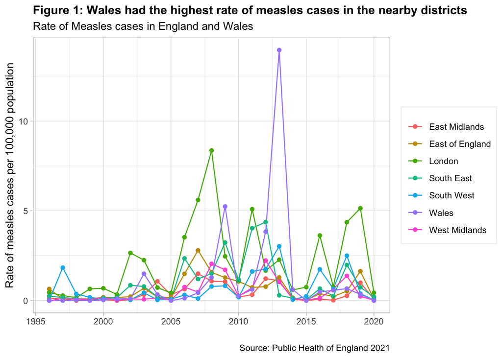

The rate of measles cases in Wales was abnormally high in the 2013 outbreak; the rate was higher than all of London’s and South East’s records, both of the higher density population zones. In addition, some sources linked the measles outbreak with The Lancet’s article and the campaign in the *South Wales Evening Post* against the MMR vaccine[^14], as most of those infected were not immunized as infants during the MMR scare.

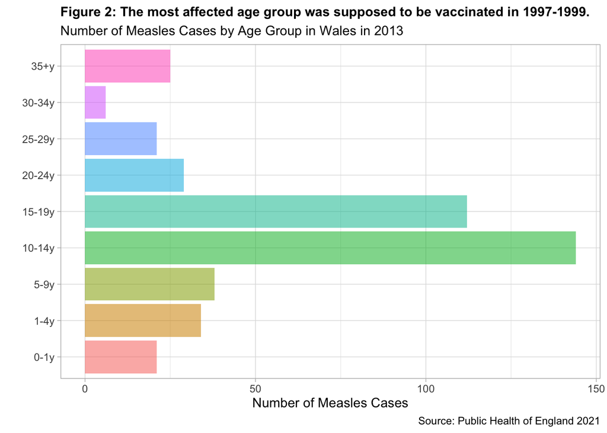

The cost of treating the sick and controlling the outbreak exceeded £470,000 ($701,898)[^15]. In 2018 WHO Europe announced that the United Kingdom (UK) lost the measles elimination status[^16].

## 3. Data and Motivating Evidence

### 3.1 Data

We will use the same data as Brendan Mason and Peter Donnelly on the measles mumps and rubella (MMR) vaccine uptake in the United Kingdom through the COVER/Korner programme, and Nomis’ national census data of Wales to control for demographic characteristics.

- The COVER/Korner programme measures uptake of the MMR vaccine for children resident in a district on the evaluation date who reached their second birthday during the previous quarter[^17]; children are scheduled to receive the first MMR immunization at 12 months.
- Nomis is a service provided by the Office for National Statistics that contains census data from 1961 to 2011 and other labor surveys[^18].

### 3.2 Motivating Evidence

Mason & Donnelly investigated MMR uptake in parts of two health authority areas, Morgannwg and Dyfed Powys, where the South Wales Evening Post was sold. They found that uptake declined by 13.6% in the distribution area of Swansea, Neath, Port Talbot, and Llanelli and by 2.4% in the rest of Wales[^19]. They concluded that the South Wales Evening Post campaign had a measurable and unhelpful impact over and above any adverse national publicity. However, it could not show a causal relation as an observational study.

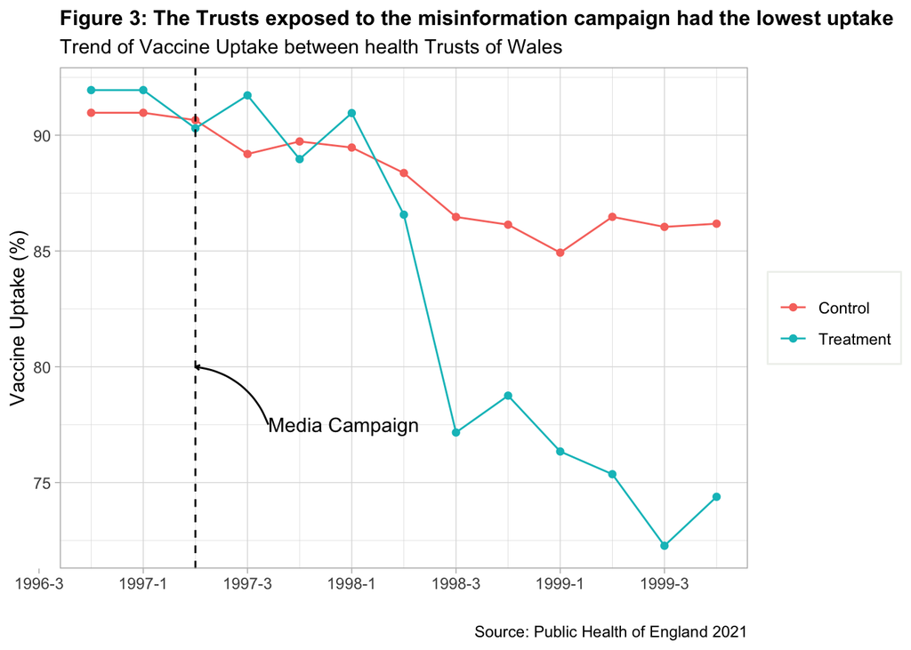

Nevertheless, separating the health trusts in Wales by exposure to the local media campaign, we can observe that the Trust that had exposure to the misinformation campaign (treatment) has considerably less vaccine uptake than the others (control). The uptake gap and the similar trend before the media campaign suggest that the misinformation campaign negatively affected vaccine uptake. We design a classic 2X2 model for this first approach to motivate the possible causal relationship. The estimator equation is given by:

$$\widehat{\delta}^{2 \times 2}_T = \left(\bar{y}_{T}^{\operatorname{post}}-\bar{y}_{T}^{\operatorname{pre}}\right)-\left(\bar{y}_{U}^{\operatorname{post}}-\bar{y}_{U}^{\operatorname{pre}}\right)$$

$\widehat{\delta}^{2 \times 2}_T$ is the estimated ATT for the group $T$, and $\bar{y}_T$ is the sample mean for that group in a particular period. The suffixes $T, U$ refer to the treatment and untreated groups.

| Table 1: Vaccine Uptake Estimates |  |  |  |
| --- | --- | --- | --- |
|  | **Treated** | **Control** | **Treatment - Control** |
| After | 81.2474443 | 87.2968601 | -6.0494158 |
|  | (7.4622335) | (1.7160912) | (5.9025785) |
| Before | 91.3970051 | 90.8620399 | 0.5349652 |
|  | (0.9526067) | (0.1838378) | (0.7687688) |
| Change in mean | **-10.1495608** | **-3.5651798** | **-6.584381** |
|  | (7.4614195) | (1.7178305) | (5.8996316) |

Therefore, the first ATT establishes a reduction of -6.58% in vaccine uptake if the health Trust was exposed to a misinformation campaign.

## Bibliography

- BBC News. «Swansea Measles Epidemic: Worries over MMR Uptake after Outbreak», 10 de julio de 2013, sec. Wales politics. https://www.bbc.com/news/uk-wales-politics-23244628.
- «Dataset Selection - Query - Nomis - Official Labour Market Statistics». Accedido 17 de marzo de 2022. https://www.nomisweb.co.uk/query/select/getdatasetbytheme.asp?opt=3&theme=&subgrp=.
- European Observatory on Health Systems and Policies, Martin McKee, Walter Ricciardi, Luigi Siciliani, Bernd Rechel, Veronica Toffolutti, David Stuckler, Alessia Melegaro, y Jan C. Semenza. «Increasing Vaccine Uptake: Confronting Misinformation and Disinformation». Eurohealth 24, n.º 3 (2018): 35-38. https://apps.who.int/iris/handle/10665/332602.
- Garett, Renee, y Sean D. Young. «Online Misinformation and Vaccine Hesitancy». Translational Behavioral Medicine 11, n.º 12 (14 de diciembre de 2021): 2194-99. https://doi.org/10.1093/tbm/ibab128.
- Loomba, Sahil, Alexandre de Figueiredo, Simon J. Piatek, Kristen de Graaf, y Heidi J. Larson. «Measuring the Impact of COVID-19 Vaccine Misinformation on Vaccination Intent in the UK and USA». Nature Human Behaviour 5, n.º 3 (marzo de 2021): 337-48. https://doi.org/10.1038/s41562-021-01056-1.
- Lyu, Hanjia, Zihe Zheng, y Jiebo Luo. «Misinformation versus Facts: Understanding the Influence of News Regarding COVID-19 Vaccines on Vaccine Uptake». Health Data Science 2022 (12 de marzo de 2022). https://doi.org/10.34133/2022/9858292.
- Mason, B., y P. Donnelly. «Impact of a local newspaper campaign on the uptake of the measles mumps and rubella vaccine». Journal of Epidemiology and Community Health 54, n.º 6 (junio de 2000): 473-74. https://doi.org/10.1136/jech.54.6.473.
- McCartney, Margaret. «MMR, Measles, and the South Wales Evening Post». BMJ 346 (22 de abril de 2013): f2598. https://doi.org/10.1136/bmj.f2598.
- Meikle, James. «Measles Outbreak Sees “missing Generation” Queuing for MMR Jab». The Guardian, 17 de abril de 2013, sec. Society. https://www.theguardian.com/society/2013/apr/17/measles-outbreak-mmr-jab.
- Pierri, Francesco, Brea Perry, Matthew R. DeVerna, Kai-Cheng Yang, Alessandro Flammini, Filippo Menczer, y John Bryden. «The impact of online misinformation on U.S. COVID-19 vaccinations». arXiv:2104.10635 [physics], 1 de mayo de 2021. http://arxiv.org/abs/2104.10635.
- Singh, Karandeep, Gabriel Lima, Meeyoung Cha, Chiyoung Cha, Juhi Kulshrestha, Yong-Yeol Ahn, y Onur Varol. «Misinformation, Believability, and Vaccine Acceptance over 40 Countries: Takeaways from the Initial Phase of the COVID-19 Infodemic». PLOS ONE 17, n.º 2 (9 de febrero de 2022): e0263381. https://doi.org/10.1371/journal.pone.0263381.
- «UK loses WHO measles elimination status, but cases remain low in Wales - Public Health Wales». Accedido 17 de marzo de 2022. https://phw.nhs.wales/news/uk-loses-who-measles-elimination-status-but-cases-remain-low-in-wales/.
- Wilson, Steven Lloyd, y Charles Wiysonge. «Social Media and Vaccine Hesitancy». BMJ Global Health 5, n.º 10 (1 de octubre de 2020): e004206. https://doi.org/10.1136/bmjgh-2020-004206.
[^1]: [Loomba et al., «Measuring the Impact of COVID-19 Vaccine Misinformation on Vaccination Intent in the UK and USA».](https://www.nature.com/articles/s41562-021-01056-1)
[^2]: [Garett y Young, «Online Misinformation and Vaccine Hesitancy».](https://pubmed.ncbi.nlm.nih.gov/34529080/)
[^3]: [European Observatory on Health Systems and Policies et al., «Increasing Vaccine Uptake».](https://apps.who.int/iris/handle/10665/332602)
[^4]: [Singh et al., «Misinformation, Believability, and Vaccine Acceptance over 40 Countries».](https://journals.plos.org/plosone/article?id=10.1371/journal.pone.0263381)
[^5]: [Garett y Young, «Online Misinformation and Vaccine Hesitancy».](https://pubmed.ncbi.nlm.nih.gov/34529080/)
[^6]: [Lyu, Zheng, y Luo, «Misinformation versus Facts».](https://spj.sciencemag.org/journals/hds/2022/9858292/)
[^7]: [Pierri et al., «The impact of online misinformation on US COVID-19 vaccinations».](https://arxiv.org/abs/2104.10635)
[^8]: [Wilson y Wiysonge, «Social Media and Vaccine Hesitancy».](https://doi.org/10.1136/bmjgh-2020-004206)
[^9]: [Mason y Donnelly, «Impact of a local newspaper campaign on the uptake of the measles mumps and rubella vaccine».](https://doi.org/10.1136/jech.54.6.473)
[^10]: [Loomba et al., «Measuring the Impact of COVID-19 Vaccine Misinformation on Vaccination Intent in the UK and USA».](https://doi.org/10.1038/s41562-021-01056-1)
[^11]: [Mason y Donnelly, «Impact of a local newspaper campaign on the uptake of the measles mumps and rubella vaccine».](https://www.ncbi.nlm.nih.gov/pmc/articles/PMC1731691/)
[^12]: [Meikle, «Measles Outbreak Sees “missing Generation” Queuing for MMR Jab».](https://www.theguardian.com/society/2013/apr/17/measles-outbreak-mmr-jab.)
[^13]: [McCartney, «MMR, Measles, and the South Wales Evening Post».](https://www.bmj.com/content/346/bmj.f2598)
[^14]: [McCartney, «MMR, Measles, and the South Wales Evening Post».](https://doi.org/10.1136/bmj.f2598)
[^15]: [BBC News «Swansea Measles Epidemic».](https://www.bbc.com/news/uk-wales-politics-23244628)
[^16]: [Public Health Wales. “UK Loses WHO Measles Elimination Status, but Cases Remain Low in Wales.” Public Health Wales.](https://phw.nhs.wales/news/uk-loses-who-measles-elimination-status-but-cases-remain-low-in-wales/)
[^17]: [Mason & Donnelly, «Impact of a local newspaper campaign on the uptake of the measles mumps and rubella vaccine».](https://jech.bmj.com/content/54/6/473)
[^18]: [«Dataset Selection - Query - Nomis - Official Labour Market Statistics».](https://www.nomisweb.co.uk/query/select/getdatasetbytheme.asp?opt=3&theme=&subgrp=)
[^19]: [Mason & Donnelly, «Impact of a local newspaper campaign on the uptake of the measles mumps and rubella vaccine».](https://jech.bmj.com/content/54/6/473)